# Analysis, Visualization and Mapping in R

## Aula 2 Objetivos

- Ganhar confiança transformando um data frame para o escopo, a estrutura e a medida apropriados para analisar

## Processando dados - Uma Lista de Ações

Primeiro, ações que definem o escopo de nossos dados:

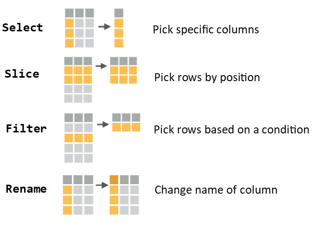

## Processing Data: Dados Originais

```r
flights
```

|  | carrier | origin | air_time | distance | dep_delay |
| --- | --- | --- | --- | --- | --- |
| 1 | UA | EWR | 227 | 1400 | 2 |
| 2 | UA | LGA | 227 | 1416 | 4 |
| 3 | AA | JFK | 160 | 1089 | 2 |
| 4 | B6 | JFK | 183 | 1576 | -1 |
| 5 | DL | LGA | 116 | 762 | -6 |

## Processando dados: Dados Originais

```r
flights %>%
  select(air_time)
```

|  | carrier | origin | air_time | distance | dep_delay |
| --- | --- | --- | --- | --- | --- |
| 1 | UA | EWR | 227 | 1400 | 2 |
| 2 | UA | LGA | 227 | 1416 | 4 |
| 3 | AA | JFK | 160 | 1089 | 2 |
| 4 | B6 | JFK | 183 | 1576 | -1 |
| 5 | DL | LGA | 116 | 762 | -6 |

## Processando dados: Select

```r
flights %>%
  select(air_time)
```

|  | air_time |
| --- | --- |
| 1 | 227 |
| 2 | 227 |
| 3 | 160 |
| 4 | 183 |
| 5 | 116 |

## Processando dados: Dados Originais

```r
flights
```

|  | carrier | origin | air_time | distance | dep_delay |
| --- | --- | --- | --- | --- | --- |
| 1 | UA | EWR | 227 | 1400 | 2 |
| 2 | UA | LGA | 227 | 1416 | 4 |
| 3 | AA | JFK | 160 | 1089 | 2 |
| 4 | B6 | JFK | 183 | 1576 | -1 |
| 5 | DL | LGA | 116 | 762 | -6 |

## Processando dados: Slice

```r
flights %>%
  slice(1:2)
```

|  | carrier | origin | air_time | distance | dep_delay |
| --- | --- | --- | --- | --- | --- |
| 1 | UA | EWR | 227 | 1400 | 2 |
| 2 | UA | LGA | 227 | 1416 | 4 |
| 3 | AA | JFK | 160 | 1089 | 2 |
| 4 | B6 | JFK | 183 | 1576 | -1 |
| 5 | DL | LGA | 116 | 762 | -6 |

## Processando dados: Slice

```r
flights %>%
  slice(1:2)
```

|  | carrier | origin | air_time | distance | dep_delay |
| --- | --- | --- | --- | --- | --- |
| 1 | UA | EWR | 227 | 1400 | 2 |
| 2 | UA | LGA | 227 | 1416 | 4 |

## Processando dados: Dados Originais

```r
flights
```

|  | carrier | origin | air_time | distance | dep_delay |
| --- | --- | --- | --- | --- | --- |
| 1 | UA | EWR | 227 | 1400 | 2 |
| 2 | UA | LGA | 227 | 1416 | 4 |
| 3 | AA | JFK | 160 | 1089 | 2 |
| 4 | B6 | JFK | 183 | 1576 | -1 |
| 5 | DL | LGA | 116 | 762 | -6 |

## Processando dados: Filter

```r
flights %>%
  filter(origin=="JFK")
```

|  | carrier | origin | air_time | distance | dep_delay |
| --- | --- | --- | --- | --- | --- |
| 1 | UA | EWR | 227 | 1400 | 2 |
| 2 | UA | LGA | 227 | 1416 | 4 |
| 3 | AA | JFK | 160 | 1089 | 2 |
| 4 | B6 | JFK | 183 | 1576 | -1 |
| 5 | DL | LGA | 116 | 762 | -6 |

## Processando dados: Filter

```r
flights %>%
  filter(origin=="JFK")
```

|  | carrier | origin | air_time | distance | dep_delay |
| --- | --- | --- | --- | --- | --- |
| 1 | AA | JFK | 160 | 1089 | 2 |
| 2 | B6 | JFK | 183 | 1576 | -1 |

## Processando dados: Filter

- Para filtrar podemos usar várias condições:
  - `==`
  - `>`, `<`
  - `<=`, `>=`
  - `&`
  - `|`
  - `%in%`
- eg. `filter(dep_delay>=0)`
- `filter(carrier %in% c("UA","DL","AA"))`
- `filter((origin=="JFK" | origin=="EWR") & carrier=="UA")`

## Processando dados: Filter

```r
flights %>%
  filter((origin=="JFK" | origin=="EWR") & carrier=="UA")
```

|  | carrier | origin | air_time | distance | dep_delay |
| --- | --- | --- | --- | --- | --- |
| 1 | UA | EWR | 227 | 1400 | 2 |
| 2 | UA | EWR | 150 | 719 | -4 |
| 3 | UA | JFK | 345 | 2475 | -2 |
| 4 | UA | EWR | 361 | 2565 | -2 |
| 5 | UA | EWR | 337 | 2227 | -1 |

## Processando dados: Filter

```r
flights %>%
  filter(origin=="JFK" & air_time<=40)
```

|  | carrier | origin | air_time | distance | dep_delay |
| --- | --- | --- | --- | --- | --- |
| 1 | AA | JFK | 38 | 187 | -7 |
| 2 | DL | JFK | 36 | 187 | -10 |
| 3 | B6 | JFK | 38 | 187 | 4 |
| 4 | AA | JFK | 40 | 187 | -8 |
| 5 | B6 | JFK | 40 | 187 | 3 |

## Processando dados: Dados Originais

```r
flights
```

|  | carrier | origin | air_time | distance | dep_delay |
| --- | --- | --- | --- | --- | --- |
| 1 | UA | EWR | 227 | 1400 | 2 |
| 2 | UA | LGA | 227 | 1416 | 4 |
| 3 | AA | JFK | 160 | 1089 | 2 |
| 4 | B6 | JFK | 183 | 1576 | -1 |
| 5 | DL | LGA | 116 | 762 | -6 |

## Processando dados: Rename

```r
flights %>%
  rename("airline"="carrier")
```

|  | carrier | origin | air_time | distance | dep_delay |
| --- | --- | --- | --- | --- | --- |
| 1 | UA | EWR | 227 | 1400 | 2 |
| 2 | UA | LGA | 227 | 1416 | 4 |
| 3 | AA | JFK | 160 | 1089 | 2 |
| 4 | B6 | JFK | 183 | 1576 | -1 |
| 5 | DL | LGA | 116 | 762 | -6 |

## Processando dados: Rename

```r
flights %>%
  rename("airline"="carrier")
```

|  | airline | origin | air_time | distance | dep_delay |
| --- | --- | --- | --- | --- | --- |
| 1 | UA | EWR | 227 | 1400 | 2 |
| 2 | UA | LGA | 227 | 1416 | 4 |
| 3 | AA | JFK | 160 | 1089 | 2 |
| 4 | B6 | JFK | 183 | 1576 | -1 |
| 5 | DL | LGA | 116 | 762 | -6 |

## Processando dados - Uma Lista de Ações

Segundo, ações para calcular a medida / estatística que precisamos

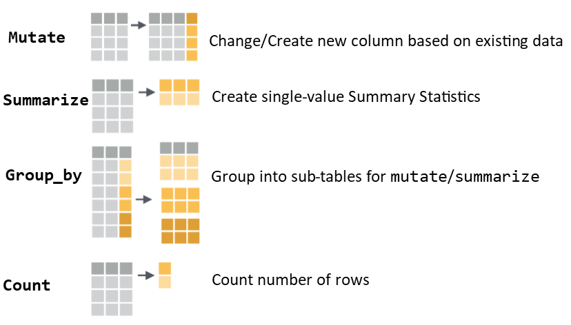

## Processing Data: Dados Originais

```r
flights
```

|  | carrier | origin | air_time | distance | dep_delay |
| --- | --- | --- | --- | --- | --- |
| 1 | UA | EWR | 227 | 1400 | 2 |
| 2 | UA | LGA | 227 | 1416 | 4 |
| 3 | AA | JFK | 160 | 1089 | 2 |
| 4 | B6 | JFK | 183 | 1576 | -1 |
| 5 | DL | LGA | 116 | 762 | -6 |

## Processando dados: Mutate

```r
flights %>%
  mutate(air_time=round(air_time/60,3))
```

|  | carrier | origin | air_time | distance | dep_delay |
| --- | --- | --- | --- | --- | --- |
| 1 | UA | EWR | 227 | 1400 | 2 |
| 2 | UA | LGA | 227 | 1416 | 4 |
| 3 | AA | JFK | 160 | 1089 | 2 |
| 4 | B6 | JFK | 183 | 1576 | -1 |
| 5 | DL | LGA | 116 | 762 | -6 |

## Processando dados: Mutate

```r
flights %>%
  mutate(air_time=round(air_time/60,3))
```

|  | carrier | origin | air_time | distance | dep_delay |
| --- | --- | --- | --- | --- | --- |
| 1 | UA | EWR | 3.783 | 1400 | 2 |
| 2 | UA | LGA | 3.783 | 1416 | 4 |
| 3 | AA | JFK | 2.667 | 1089 | 2 |
| 4 | B6 | JFK | 3.05 | 1576 | -1 |
| 5 | DL | LGA | 1.933 | 762 | -6 |

## Processando dados: Dados Originais

```r
flights
```

|  | carrier | origin | air_time | distance | dep_delay |
| --- | --- | --- | --- | --- | --- |
| 1 | UA | EWR | 227 | 1400 | 2 |
| 2 | UA | LGA | 227 | 1416 | 4 |
| 3 | AA | JFK | 160 | 1089 | 2 |
| 4 | B6 | JFK | 183 | 1576 | -1 |
| 5 | DL | LGA | 116 | 762 | -6 |

## Processando dados: Summarize

```r
flights %>%
  summarize(avg_distance=mean(distance,na.rm=TRUE))
```

|  | carrier | origin | air_time | distance | dep_delay |
| --- | --- | --- | --- | --- | --- |
| 1 | UA | EWR | 227 | 1400 | 2 |
| 2 | UA | LGA | 227 | 1416 | 4 |
| 3 | AA | JFK | 160 | 1089 | 2 |
| 4 | B6 | JFK | 183 | 1576 | -1 |
| 5 | DL | LGA | 116 | 762 | -6 |

## Processando dados: Summarize

```r
flights %>%
  summarize(avg_distance=mean(distance,na.rm=TRUE))
```

|  | avg_distance |
| --- | --- |
| 1 | 1248.6 |

## Processando dados: Dados Originais

```r
flights
```

|  | carrier | origin | air_time | distance | dep_delay |
| --- | --- | --- | --- | --- | --- |
| 1 | UA | EWR | 227 | 1400 | 2 |
| 2 | UA | LGA | 227 | 1416 | 4 |
| 3 | AA | JFK | 160 | 1089 | 2 |
| 4 | B6 | JFK | 183 | 1576 | -1 |
| 5 | DL | LGA | 116 | 762 | -6 |

## Processando dados: Count

```r
flights %>%
  count()
```

|  | n |
| --- | --- |
| 1 | 336776 |

## Processando dados: Dados Originais

```r
flights
```

|  | carrier | origin | air_time | distance | dep_delay |
| --- | --- | --- | --- | --- | --- |
| 1 | UA | EWR | 227 | 1400 | 2 |
| 2 | UA | LGA | 227 | 1416 | 4 |
| 3 | AA | JFK | 160 | 1089 | 2 |
| 4 | B6 | JFK | 183 | 1576 | -1 |
| 5 | DL | LGA | 116 | 762 | -6 |

## Processando dados: Group_by

```r
flights %>%
  group_by(carrier) %>%
  summarize(avg_distance=mean(distance,na.rm=TRUE))
```

|  | carrier | origin | air_time | distance | dep_delay |
| --- | --- | --- | --- | --- | --- |
| 1 | UA | EWR | 227 | 1400 | 2 |
| 2 | UA | LGA | 227 | 1416 | 4 |
| 3 | AA | JFK | 160 | 1089 | 2 |
| 4 | B6 | JFK | 183 | 1576 | -1 |
| 5 | DL | LGA | 116 | 762 | -6 |

## Processando dados: Group_by

```r
flights %>%
  group_by(carrier) %>%
  summarize(avg_distance=mean(distance,na.rm=TRUE))
```

|  | carrier | avg_distance |
| --- | --- | --- |
| 1 | AA | 1089 |
| 2 | B6 | 1576 |
| 3 | DL | 762 |
| 4 | UA | 1408 |

## Processando dados - Uma Lista de Ações

Terceiro, ações que reestruturam nossos dados:

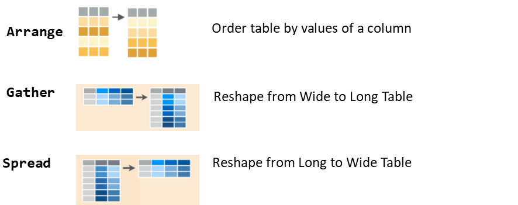

## Processing Data: Dados Originais

```r
flights
```

|  | carrier | origin | air_time | distance | dep_delay |
| --- | --- | --- | --- | --- | --- |
| 1 | UA | EWR | 227 | 1400 | 2 |
| 2 | UA | LGA | 227 | 1416 | 4 |
| 3 | AA | JFK | 160 | 1089 | 2 |
| 4 | B6 | JFK | 183 | 1576 | -1 |
| 5 | DL | LGA | 116 | 762 | -6 |

## Processando dados: Arrange

```r
flights %>%
  arrange(air_time)
```

|  | carrier | origin | air_time | distance | dep_delay |
| --- | --- | --- | --- | --- | --- |
| 1 | UA | EWR | 227 | 1400 | 2 |
| 2 | UA | LGA | 227 | 1416 | 4 |
| 3 | AA | JFK | 160 | 1089 | 2 |
| 4 | B6 | JFK | 183 | 1576 | -1 |
| 5 | DL | LGA | 116 | 762 | -6 |

## Processando dados: Arrange

```r
flights %>%
  arrange(air_time)
```

|  | carrier | origin | air_time | distance | dep_delay |
| --- | --- | --- | --- | --- | --- |
| 1 | DL | LGA | 116 | 762 | -6 |
| 2 | AA | JFK | 160 | 1089 | 2 |
| 3 | B6 | JFK | 183 | 1576 | -1 |
| 4 | UA | EWR | 227 | 1400 | 2 |
| 5 | UA | LGA | 227 | 1416 | 4 |

## Processando dados: Arrange

```r
flights %>%
  arrange(-air_time)
```

|  | carrier | origin | air_time | distance | dep_delay |
| --- | --- | --- | --- | --- | --- |
| 1 | UA | EWR | 227 | 1400 | 2 |
| 2 | UA | LGA | 227 | 1416 | 4 |
| 3 | AA | JFK | 160 | 1089 | 2 |
| 4 | B6 | JFK | 183 | 1576 | -1 |
| 5 | DL | LGA | 116 | 762 | -6 |

## Processando dados: Arrange

```r
flights %>%
  arrange(-air_time)
```

|  | carrier | origin | air_time | distance | dep_delay |
| --- | --- | --- | --- | --- | --- |
| 1 | UA | EWR | 227 | 1400 | 2 |
| 2 | UA | LGA | 227 | 1416 | 4 |
| 3 | B6 | JFK | 183 | 1576 | -1 |
| 4 | AA | JFK | 160 | 1089 | 2 |
| 5 | DL | LGA | 116 | 762 | -6 |

## Processando dados: Dados Originais

```r
flights
```

|  | carrier | origin | dep_delay |
| --- | --- | --- | --- |
| 1 | UA | EWR | 2 |
| 2 | UA | LGA | 4 |
| 3 | AA | JFK | 2 |
| 4 | B6 | JFK | -1 |
| 5 | DL | LGA | -6 |

## Processando dados: Spread

```r
flights %>%
  spread(key="origin",value="dep_delay")
```

|  | carrier | origin | dep_delay |
| --- | --- | --- | --- |
| 1 | UA | EWR | 2 |
| 2 | UA | LGA | 4 |
| 3 | AA | JFK | 2 |
| 4 | B6 | JFK | -1 |
| 5 | DL | LGA | -6 |

## Processando dados: Spread

```r
flights %>%
  spread(key="origin",value="dep_delay")
```

|  | carrier | EWR | JFK | LGA |
| --- | --- | --- | --- | --- |
| 1 | AA |  | 2 |  |
| 2 | B6 |  | -1 |  |
| 3 | DL |  |  | -6 |
| 4 | UA | 2 |  | 4 |

## Processando dados: Dados Originais

```r
flights
```

|  | carrier | origin | air_time | distance | dep_delay |
| --- | --- | --- | --- | --- | --- |
| 1 | UA | EWR | 227 | 1400 | 2 |
| 2 | UA | LGA | 227 | 1416 | 4 |
| 3 | AA | JFK | 160 | 1089 | 2 |
| 4 | B6 | JFK | 183 | 1576 | -1 |
| 5 | DL | LGA | 116 | 762 | -6 |

## Processando dados: Gather

```r
flights %>%
  gather(key="measure",value="value",-c(carrier,origin))
```

|  | carrier | origin | air_time | distance | dep_delay |
| --- | --- | --- | --- | --- | --- |
| 1 | UA | EWR | 227 | 1400 | 2 |
| 2 | UA | LGA | 227 | 1416 | 4 |
| 3 | AA | JFK | 160 | 1089 | 2 |
| 4 | B6 | JFK | 183 | 1576 | -1 |
| 5 | DL | LGA | 116 | 762 | -6 |

## Processando dados: Gather

```r
flights %>%
  gather(key="measure",value="value",-c(carrier,origin))
```

|  | carrier | origin | measure | value |
| --- | --- | --- | --- | --- |
| 1 | UA | EWR | air_time | 227 |
| 2 | UA | LGA | air_time | 227 |
| 3 | AA | JFK | air_time | 160 |
| 4 | B6 | JFK | air_time | 183 |
| 5 | DL | LGA | air_time | 116 |
| 6 | UA | EWR | distance | 1400 |
| 7 | UA | LGA | distance | 1416 |
| 8 | AA | JFK | distance | 1089 |
| 9 | B6 | JFK | distance | 1576 |
| 10 | DL | LGA | distance | 762 |

[output cut: 5 more lines]

## Estratégias com Dados

Cada analise precisa uma sequência diferente de ações, mas uma estratégia geral é:

1. **Defina sua pergunta de pesquisa**
   - Desenhe seu data frame desejado primeiro!
2. **Refine o escopo da análise**
   - `filter` para as linhas relevantes
   - `select` e `rename` para tirar dados desnecessários
3. **'Split' os dados em subgrupos para análise** (se necessário)
   - `group_by` subgrupos
4. **'Apply' um cálculo ou resumo estatístico para cada subgrupo**
   - `summarize` ou `mutate`
5. **'Combine' para a sua unidade de análise desejada**
   - `spread`/`gather` o data frame para que cada linha é uma unidade
   - `arrange` o data frame na ordem desejado

## Estratégias com Dados

1. **Defina sua pergunta de pesquisa**
   - Qual é o atraso médio para cada mês para cada companhia aérea que sai do JFK?
2. **Refine o escopo da análise**
   - `filter` só para JFK
   - `select` as variáveis de companhia aérea, mês e atraso
3. **'Split' os dados em subgrupos para análise**
   - `group_by` companhia aérea e mês
4. **'Apply' um cálculo ou resumo estatístico para cada subgrupo**
   - `summarize` para calcular o atraso médio
5. **'Combine' para a sua unidade de análise desejada**
   - `spread` o data frame para que cada companhia aérea é uma linha e cada mês é uma coluna

## Estratégias com Dados

2 - Refine o escopo da análise  
- `filter` só para JFK

```r
flights_analysis <- flights %>% filter(origin=="JFK")
```

|  | carrier | origin | air_time | distance | dep_delay | month |
| --- | --- | --- | --- | --- | --- | --- |
| 1 | AA | JFK | 160 | 1089 | 2 | 1 |
| 2 | B6 | JFK | 183 | 1576 | -1 | 1 |
| 3 | B6 | JFK | 140 | 944 | -3 | 1 |
| 4 | B6 | JFK | 149 | 1028 | -2 | 1 |
| 5 | B6 | JFK | 158 | 1005 | -2 | 1 |

## Estratégias com Dados

2 - Refine o escopo da análise  
- `select` as variáveis de companhia aérea, mês e atraso

```r
flights_analysis <- flights_analysis %>%
  select(carrier,month,dep_delay)
```

|  | carrier | month | dep_delay |
| --- | --- | --- | --- |
| 1 | AA | 1 | 2 |
| 2 | B6 | 1 | -1 |
| 3 | B6 | 1 | -3 |
| 4 | B6 | 1 | -2 |
| 5 | B6 | 1 | -2 |

## Estratégias com Dados

3 - 'Split' os dados em subgrupos para análise  
- `group_by` companhia aérea e mês

```r
flights_analysis <- flights_analysis %>%
  group_by(carrier,month)
```

[output not shown]

## Estratégias com Dados

4 - 'Apply' um cálculo ou resumo estatístico para cada subgrupo  
- `summarize` para calcular o atraso médio

```r
flights_analysis <- flights_analysis %>%
  summarize(avg_delay=mean(dep_delay,na.rm=TRUE))
```

|  | carrier | month | avg_delay |
| --- | --- | --- | --- |
| 1 | 9E | 1 | 16.88 |
| 2 | 9E | 2 | 16.49 |
| 3 | 9E | 3 | 13.41 |
| 4 | 9E | 4 | 13.57 |
| 5 | 9E | 5 | 22.67 |
| 6 | AA | 1 | 6.93 |
| 7 | AA | 2 | 8.28 |
| 8 | AA | 3 | 8.7 |
| 9 | AA | 4 | 11.7 |
| 10 | AA | 5 | 9.66 |

[output cut: 70 more lines]

## Estratégias com Dados

5 - 'Combine' para a sua unidade de análise desejada  
- `spread` o data frame para que cada companhia aérea é uma linha e cada mês é uma coluna

```r
flights_analysis <- flights_analysis %>%
  spread(key="month",value="avg_delay")
```

|  | carrier | 1 | 2 | 3 | 4 | 5 | 6 | 7 | 8 | 9 | 10 | 11 | 12 |
| --- | --- | --- | --- | --- | --- | --- | --- | --- | --- | --- | --- | --- | --- |
| 1 | 9E | 16.88 | 16.49 | 13.41 | 13.57 | 22.67 | 28.95 | 31.4 | 17.3 | 7.75 | 9.33 | 7.56 | 19.78 |
| 2 | AA | 6.93 | 8.28 | 8.7 | 11.7 | 9.66 | 14.63 | 12.11 | 7.17 | 5.69 | 3 | 3.1 | 11.71 |
| 3 | AS | 7.35 | 0.72 | 8.42 | 11.32 | 6.77 | 13.08 | 2.42 | 2.87 | -4.52 | 0.68 | 3.08 | 18.02 |
| 4 | B6 | 9.49 | 13.77 | 14.24 | 15.17 | 9.78 | 20.39 | 24.9 | 15.68 | 6.63 | 2.96 | 3.52 | 17 |
| 5 | DL | 3.85 | 5.54 | 9.93 | 8.17 | 9.74 | 18.74 | 20.58 | 9.85 | 5.53 | 3.42 | 2.85 | 10.79 |

## Estratégias com Dados

Tudo juntos:

```r
flights_analysis <- flights %>% filter(origin=="JFK") %>%
  select(carrier,month,dep_delay) %>%
  group_by(carrier,month) %>%
  summarize(avg_delay=mean(dep_delay,na.rm=TRUE)) %>%
  spread(key="month",value="avg_delay")
```

## Estratégias com Dados

1 - Qual é a média de distâncias de voos saindo de LaGuardia (LGA)?

```r
flights %>%
  filter(origin=="LGA") %>%
  summarize(avg_distance=mean(distance,na.rm=TRUE))
```

|  | avg_distance |
| --- | --- |
| 1 | 779.835671017179 |

## Estratégias com Dados

2 - Qual é a velocidade média dos voos de cada aeroporto de origem?

```r
flights %>%
  group_by(origin) %>%
  mutate(speed=distance/air_time) %>%
  summarize(avg_speed=mean(speed,na.rm=TRUE))
```

[output not shown]

## Estratégias com Dados

3 - Qual é o destino do voo mais rápido operado pela American Airlines (AA)?

```r
flights %>%
  filter(carrier=="AA") %>%
  mutate(speed=distance/air_time) %>%
  arrange(-speed) %>%
  slice(1) %>%
  select(dest)
```

|  | dest |
| --- | --- |
| 1 | STT |

## Estratégias com Dados

4 - Qual é o desvio padrão dos atrasos de partida em cada mês?

```r
flights %>%
  group_by(month) %>%
  summarize(sd_delays=sd(dep_delay,na.rm=TRUE))
```

|  | month | sd_delays |
| --- | --- | --- |
| 1 | 1 | 36.390312823488 |
| 2 | 2 | 36.2665531369193 |
| 3 | 3 | 40.1309674957311 |
| 4 | 4 | 42.9662606612537 |
| 5 | 5 | 39.3528345091621 |
| 6 | 6 | 51.4569394330548 |
| 7 | 7 | 51.6160755473808 |
| 8 | 8 | 37.666923284766 |
| 9 | 9 | 35.6147982156469 |
| 10 | 10 | 29.6717613035359 |

[output cut: 2 more lines]

## Estratégias com Dados

```r
flights %>%
  filter(month==5 & hour>=10) %>%
  group_by(carrier) %>%
  count() %>%
  ungroup() %>%
  arrange(-n) %>%
  slice(1) %>%
  select(carrier)
```

|  | carrier |
| --- | --- |
| 1 | UA |

## Resultados In-Line

Queremos encontrar a velocidade média dos voos da United (UA).

```r
avg_speed <- flights %>% filter(carrier=="UA") %>%
  mutate(speed=distance/(air_time/60)) %>%
  summarize(avg_speed=mean(speed,na.rm=TRUE)) %>%
  round(1)
```

A velocidade média dos vôos da United é `` `r avg_speed` `` milhas por hora.

A velocidade média dos vôos da United é 420.9 milhas por hora.